### Embedding a Demand Function into an ARIMA Model:

### Regression with ARIMA Errors Laboratory.

#### (Total 40 pts.)

#### Due: Dec. 5

The sales data is provided in CSV format in the file **“PBS.csv”**. As this is an individual skill-building assignment (as opposed to an open-ended team assignment), and I would like to achieve some degree of convergence in your answers, hence I have provided a common data preprocessing script below. The data set corresponds to the total weekly sales of peanut butter for a supermarket chain, not for the individual stores. As you can observe from the file, the data corresponds to a combination of multiple brands as well as the supermarket private label (generic) in sizes ranging from 0.75 to 1.5 lbs.

The data includes the following information for each individual stock keeping unit (SKU) as identified by its UPC code on each week in the data file:

- VEND Number identifying the product vendor (48001 corresponds to Unilever).
- UPC The product’s universal product code (bar code)
- UNITS Sales volume
- DOLLARS Dollar sales revenue
- VOL_EQ Weight in pounds of a units sold
- PPU Price per unit ($/lb)
- F Factor specifying advertising in the store weekly flyer:
  - F = “A+” Large size ad.
  - F = “A” Medium size ad.
  - F = “B” Small size ad.
- D Factor specifying In-Store Display
  - D = 0 No In-Store Display
  - D = 1 In-Store Display

To simplify the modeling process (and the assignment) in the preprocessing script below I lumped all products into just three aggregate products (sub-categories): “SK” includes all Skippy brand products, “OB” includes all other branded products and “PL” includes all private label products. For each of the three aggregate products I obtained the total sales (volume) in pounds, the average sale prices ($/lb), and volume-weighted averages of the advertising and display variables (F and D). Please take a few minutes to examine the pre-processing script below.

Our goal is to embed a log-log demand model in an ARIMA model (Regression with ARIMA errors) that accounts for the auto-correlations in the sales data. As a first attempt we would like to include a demand function of the following form:

$$y=e^{βx} p_S^α p_B^γ
p_P^{γ_o}$$

Where the model variables and parameters are defined as follows:

- $y$ : Demand (sales volume)
- $p_S$ : Average price per pound of “Skippy” products
- $p_B$ : Average price per pound of “Other Branded” products
- $p_P$ : Average price per pound of “Private Label” products
- $x$ : Vector of weighted averages of advertising and display variables for each product sub-category
- $β$ : Vector of coefficients for advertising and display variables
- $α,γ,γ_o$: Coefficients (elasticity and cross-elasticities) of prices

We have a total of 104 weeks of data. In this assignment we will use weeks 1 through 94 as a training set and weeks 95 through 104 as a testing set.

```r
library(fpp3)
library(reshape2)
library(glmnet)
library(coefplot)
library(lubridate)
rm(list=ls())

# Data Pre-Processing
#
PBS <- read.csv("PBS.csv") %>%
  mutate( F_LSA=ifelse(F=="A+",1,0),      # Large Size Ad Dummy
          F_MSA=ifelse(F=="A",1,0),       # Medium Size Ad Dummy
          F_SSA=ifelse(F=="B",1,0)) %>%   # Small Size Ad Dummy
  # Promotional variables are weighted by sales volume (oz)
  mutate(S_LB = UNITS * VOL_EQ,
         WF_LSA = F_LSA * S_LB,     # Large Size Ad Weighted
         WF_MSA = F_MSA * S_LB,     # Medium Size Ad Weighted
         WF_SSA = F_SSA * S_LB,     # Small Size Ad Weighted
         WD     = D * S_LB) %>%     # In-Store Display Weighted

  mutate(VEND =ifelse(VEND == 48001,"SK",ifelse( VEND == 99998,"PL","OB"))) %>%
  select(-F)

# Create aggregate variables by product-week
x.pw <- PBS %>% group_by(WEEK, VEND) %>%
  summarise(S.DOLLARS = sum(DOLLARS),      # Total $ Sales
            S.S_LB    = sum(S_LB),         # Total L. Sales
            S.WF_LSA  = sum(WF_LSA),       # Total Weighted Large Ad
            S.WF_MSA  = sum(WF_MSA),       # Total Weighted Medium Ad
            S.WF_SSA  = sum(WF_SSA),       # Total Weighted Small Ad
            S.WD      = sum(WD)) %>%       # Total Weighted Store Disp
  # Calculate weigted averages of Advertising and Promotion variables
  mutate(A.PPU = log(S.DOLLARS / S.S_LB),  # Log of Avg. Price ($/pound)
         S.WF_LSA  = S.WF_LSA / S.S_LB,    # Avg. Weighted Large Ad
         S.WF_MSA  = S.WF_MSA / S.S_LB,    # Avg. Weighted Medium Ad
         S.WF_SSA  = S.WF_SSA / S.S_LB,    # Avg. Weighted Small Ad
         S.WD      = S.WD / S.S_LB)        # Avg. Weighted Store Disp

#
x.pw <- x.pw %>%
  mutate(LS  = log(S.S_LB)) %>%
  select(-S.DOLLARS, -S.S_LB)
#
# Creeate separate dataframes for each brand group
x.SK <- x.pw %>% filter(VEND == "SK") %>% select(-VEND)
colnames(x.SK) <- c("WEEK","WF_LSA.SK","WF_MSA.SK","WF_SSA.SK","S.WD.SK","PPU.SK","LS.SK" )
x.OB <- x.pw %>% filter(VEND == "OB") %>% select(-VEND,-LS)
colnames(x.OB) <- c("WEEK","WF_LSA.OB","WF_MSA.OB","WF_SSA.OB","S.WD.OB","PPU.OB")
x.PL <- x.pw %>% filter(VEND == "PL") %>% select(-VEND,-LS)
colnames(x.PL) <- c("WEEK","WF_LSA.PL","WF_MSA.PL","WF_SSA.PL","S.WD.PL","PPU.PL")

#Join the product-specific dataframes to create an expanded dataframe for SK using the
# data from competing products as additional columns to be used as predicitve variables

xmat <- x.SK %>%
  left_join(x.OB,by="WEEK") %>%
  left_join(x.PL,by="WEEK")

# If your code executed correctly xmat should have 17 cols and 104 rows.
#
xm <- model.matrix(LS.SK ~(. - WEEK)^2 , data=xmat)[,-1]
y <- xmat$LS.SK

#Separation of Training and Testing sets
xm.tr <- xm[1:94,]
y.tr <-  y[1:94]
xm.te <- xm[95:104,]
y.te <-  y[95:104]
#
```

### Ques 1: (5 pts) After pre-processing the data, notice that you have 120 predictive variables plus the sales vector. Notice that the pre-processing step already computes the log of the average prices and sales volumes. Now use The Lasso on the training set to obtain (a) a regularized model and (b) the reduced set of predictive variables that minimize the cross-validated MSE over the training set (i.e., the set of variables included in the Lasso-regularized model). (Use set.seed(1) before 10-fold cross-validation). Report the coefficients of the regularized model.

**Ans 1:**

**(a) LASSO regularized model:**

```r
set.seed(1)
#cross-validation using k=10
lasso = cv.glmnet(xm.tr, y.tr, alpha=1 ,k = 10)

#finding optimal lambda when the MSE is lowest
lambda = lasso$lambda.min
cat("The optimal value of lambda when MSE is lowest is: ", lambda)
```

```
## The optimal value of lambda when MSE is lowest is:  0.06232256
```

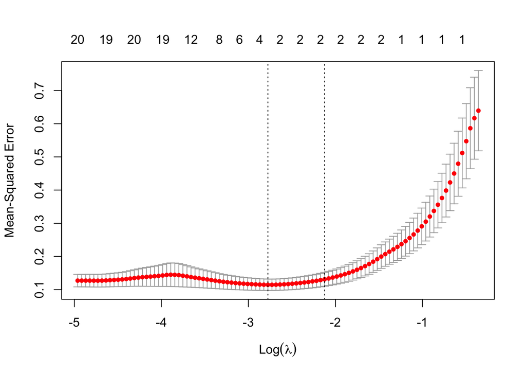

```r
#plotting the MSE vs lambda
plot(lasso)
```

**(b) The reduced set of predictive variables:**

```r
# non-zero coefficients
lasso_best= glmnet(xm.tr, y.tr, alpha=1, lambda = lambda)
non_zero_coef = coef(lasso_best)
cat("Non-zero coefficients:\n")
```

```
## Non-zero coefficients:
```

```r
print(non_zero_coef[non_zero_coef[,1]!=0,])
```

```
##      (Intercept)           PPU.SK WF_LSA.SK:PPU.OB   S.WD.SK:PPU.OB
##       6.67517845      -2.32508143       0.06665459       0.02517166
##   S.WD.SK:PPU.PL
##       0.58850344
```

### Ques 2: (5 pts) Use the training set to fit an unrestricted regression model (i.e., **lm(…)** ) on the reduced set of explanatory variables identified by The Lasso. Report the coefficients of the full model and comment on the fit of the model and examine the auto-correlations of the residuals of this model.

**Ans 2:**

```r
#unrestricted model

unrest_lasso = lm(y.tr ~ xm.tr[,"PPU.SK"]+xm.tr[,"WF_LSA.SK:PPU.OB"]+xm.tr[,"S.WD.SK:PPU.OB"]+xm.tr[,"S.WD.SK:PPU.PL"])

#printing model
print(unrest_lasso)
```

```
##
## Call:
## lm(formula = y.tr ~ xm.tr[, "PPU.SK"] + xm.tr[, "WF_LSA.SK:PPU.OB"] +
##     xm.tr[, "S.WD.SK:PPU.OB"] + xm.tr[, "S.WD.SK:PPU.PL"])
##
## Coefficients:
##                 (Intercept)            xm.tr[, "PPU.SK"]
##                      6.8755                      -2.5771
## xm.tr[, "WF_LSA.SK:PPU.OB"]    xm.tr[, "S.WD.SK:PPU.OB"]
##                      0.5311                       0.2433
##   xm.tr[, "S.WD.SK:PPU.PL"]
##                      0.5045
```

```r
#printing summary
summary(unrest_lasso)
```

```
##
## Call:
## lm(formula = y.tr ~ xm.tr[, "PPU.SK"] + xm.tr[, "WF_LSA.SK:PPU.OB"] +
##     xm.tr[, "S.WD.SK:PPU.OB"] + xm.tr[, "S.WD.SK:PPU.PL"])
##
## Residuals:
##      Min       1Q   Median       3Q      Max
## -0.86712 -0.15683  0.01025  0.21102  0.82141
##
## Coefficients:
##                             Estimate Std. Error t value Pr(>|t|)
## (Intercept)                   6.8755     0.1284  53.545   <2e-16 ***
## xm.tr[, "PPU.SK"]            -2.5771     0.1320 -19.525   <2e-16 ***
## xm.tr[, "WF_LSA.SK:PPU.OB"]   0.5311     0.2534   2.096   0.0389 *
## xm.tr[, "S.WD.SK:PPU.OB"]     0.2433     0.7016   0.347   0.7296
## xm.tr[, "S.WD.SK:PPU.PL"]     0.5045     0.7584   0.665   0.5077
## ---
## Signif. codes:  0 '***' 0.001 '**' 0.01 '*' 0.05 '.' 0.1 ' ' 1
##
## Residual standard error: 0.3143 on 89 degrees of freedom
## Multiple R-squared:  0.8514, Adjusted R-squared:  0.8447
## F-statistic: 127.5 on 4 and 89 DF,  p-value: < 2.2e-16
```

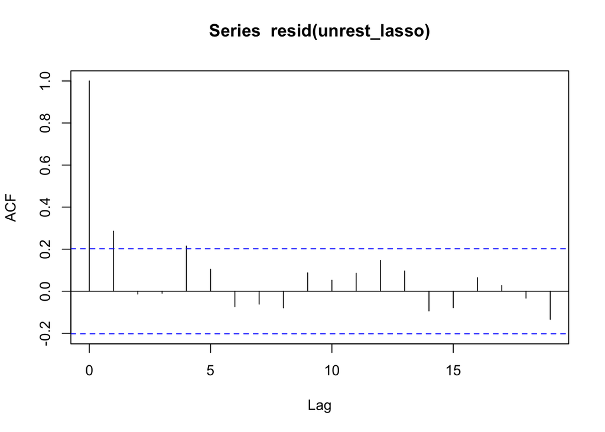

```r
# checking autocorrelation
acf(resid(unrest_lasso))
```

```r
lasso_resi = unrest_lasso$res
length = length(lasso_resi)
resi = lm(lasso_resi[-length] ~ lasso_resi[-1])
summary(resi)
```

```
##
## Call:
## lm(formula = lasso_resi[-length] ~ lasso_resi[-1])
##
## Residuals:
##      Min       1Q   Median       3Q      Max
## -0.83427 -0.21675  0.00439  0.19702  0.71504
##
## Coefficients:
##                Estimate Std. Error t value Pr(>|t|)
## (Intercept)    0.005714   0.030415   0.188  0.85139
## lasso_resi[-1] 0.286594   0.099034   2.894  0.00476 **
## ---
## Signif. codes:  0 '***' 0.001 '**' 0.01 '*' 0.05 '.' 0.1 ' ' 1
##
## Residual standard error: 0.2933 on 91 degrees of freedom
## Multiple R-squared:  0.08427,    Adjusted R-squared:  0.07421
## F-statistic: 8.375 on 1 and 91 DF,  p-value: 0.004762
```

As visible from acf and summary, the auto-correlations exists between residuals. At lag 0, there is correlation of 1 and at lag 1 of 0.3

### Ques 3: (5 pts) Reorganize the data as a **tsibble** and the use the **ARIMA()** function to fit a simple ARIMA model (not a regression with ARIMA errors model) to explain the training set log-of-sales-volume data. Report the diagnostic of your model’s residuals and comment on the model’s validity.

**Ans 3:**

```r
#splitting into training and testing set
xmat.tr = xmat[1:94,]
xmat.te = xmat[95:104,]

#tssible
ARIMA_tr = xmat.tr %>% as_tsibble(index=WEEK)

ARIMA_te = xmat.te %>% as_tsibble(index=WEEK)

#fit ARIMA Model
ARIMA_fit = ARIMA_tr %>% model(model_ARIMA = ARIMA(LS.SK))

ARIMA_fit %>% glance()
```

| .model | sigma2 | log_lik | AIC | AICc | BIC | ar_roots | ma_roots |
| --- | --- | --- | --- | --- | --- | --- | --- |
| model_ARIMA | 0.415269 | -90.50823 | 191.0165 | 191.6983 | 203.7329 |  |  |

```r
ARIMA_fit %>% report()
```

```
## Series: LS.SK
## Model: ARIMA(2,0,1) w/ mean
##
## Coefficients:
##          ar1      ar2     ma1  constant
##       0.0363  -0.3600  0.5797    6.1316
## s.e.  0.1711   0.1271  0.1818    0.1029
##
## sigma^2 estimated as 0.4153:  log likelihood=-90.51
## AIC=191.02   AICc=191.7   BIC=203.73
```

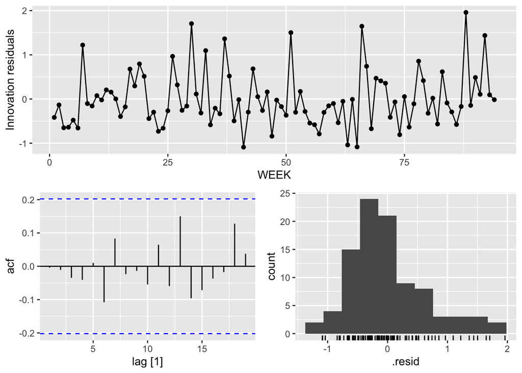

```r
ARIMA_fit  %>%  gg_tsresiduals()
```

```r
#performing ljung_box test
ARIMA_fit %>%
  augment() %>%
  features(.resid, ljung_box)
```

| .model | lb_stat | lb_pvalue |
| --- | --- | --- |
| model_ARIMA | 0.001746853 | 0.9666618 |

As visible from acf, the auto-correlations does not exist between residuals. This is also confirmed by *ljung box* where lb_pvalue is ~0.97. **This is a valid model**

### Ques 4: (5 pts) Use the model in Question 3 to prepare a 10 period ahead forecast and compare it (overly it) with the testing set log-of-sales data. Comment on the usefulness of this model in terms of precision and confidence interval.

**Ans 4:**

```r
for_mod_1 = ARIMA_fit %>% forecast(h=10)

fit_mod_1 = ARIMA_fit %>%  augment()

rbind(for_mod_1 %>% accuracy(data = ARIMA_te), ARIMA_fit %>% accuracy())
```

| .model | .type | ME | RMSE | MAE | MPE | MAPE | MASE | RMSSE | ACF1 |
| --- | --- | --- | --- | --- | --- | --- | --- | --- | --- |
| model_ARIMA | Test | 0.2983326476 | 0.7847687 | 0.5446611 | 4.337612 | 10.12916 | NaN | NaN | 0.410264843 |
| model_ARIMA | Training | -0.0001286775 | 0.6305537 | 0.4741080 | -1.696712 | 10.05719 | 0.726594 | 0.6674057 | -0.004242972 |

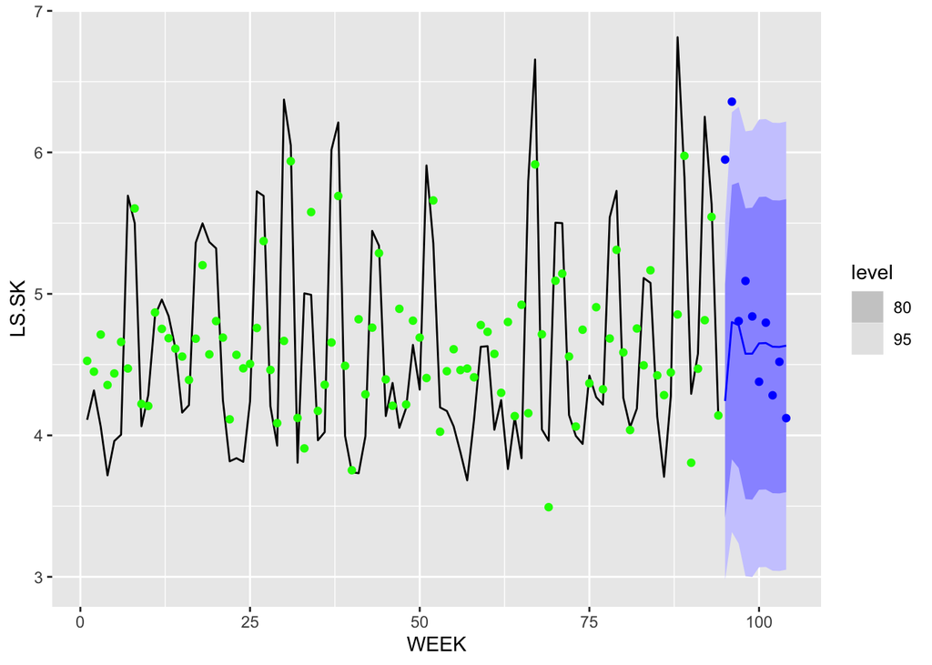

```r
for_mod_1 %>% autoplot(ARIMA_tr) +
          geom_point(data = fit_mod_1, mapping = aes(y = .fitted), col = "green") +
          geom_point(data = ARIMA_te, mapping = aes(y = LS.SK), col = "blue")
```

```r
for_mod_1 %>% hilo(level =95) %>% unpack_hilo("95%") %>% mutate(Actual = ARIMA_te$LS.SK)
```

| .model | WEEK | LS.SK | .mean | 95%_lower | 95%_upper | Actual |
| --- | --- | --- | --- | --- | --- | --- |
| model_ARIMA | 95 |  | 4.242786 | 2.979758 | 5.505813 | 5.949061 |
| model_ARIMA | 96 |  | 4.800380 | 3.316938 | 6.283821 | 6.358260 |
| model_ARIMA | 97 |  | 4.778436 | 3.234916 | 6.321956 | 4.807829 |
| model_ARIMA | 98 |  | 4.576903 | 3.005335 | 6.148470 | 5.091298 |
| model_ARIMA | 99 |  | 4.577485 | 2.999444 | 6.155526 | 4.840561 |
| model_ARIMA | 100 |  | 4.650059 | 3.068077 | 6.232041 | 4.378946 |
| model_ARIMA | 101 |  | 4.652484 | 3.069794 | 6.235175 | 4.796432 |
| model_ARIMA | 102 |  | 4.626446 | 3.043201 | 6.209691 | 4.283043 |
| model_ARIMA | 103 |  | 4.624627 | 3.041306 | 6.207948 | 4.519785 |
| model_ARIMA | 104 |  | 4.633935 | 3.050537 | 6.217333 | 4.121650 |

### Ques 5: (5 pts) Use the **ARIMA()** function to automatically fit a regression with ARIMA errors model to explain sales data (log) using only the predictive variables identified by The Lasso in Question 1. Examine the model’s residuals and comment on its validity.

**Ans 5:** The predictive variables from the LASSO from Question 1 are: PPU.SK, WF_LSA.SK:PPU.OB, S.WD.SK:PPU.OB and S.WD.SK:PPU.PL

```r
#Model with best lasso variables
fit_mod_2 = ARIMA_tr %>% model(model_2 = ARIMA(LS.SK ~ PPU.SK + WF_LSA.SK:PPU.OB + S.WD.SK:PPU.OB + S.WD.SK:PPU.PL))

#printing summary and coefficients
fit_mod_2 %>% glance()
```

| .model | sigma2 | log_lik | AIC | AICc | BIC | ar_roots | ma_roots |
| --- | --- | --- | --- | --- | --- | --- | --- |
| model_2 | 0.08606766 | -15.66163 | 45.32327 | 46.64092 | 63.05146 |  |  |

```r
fit_mod_2 %>% report()
```

```
## Series: LS.SK
## Model: LM w/ ARIMA(0,1,2) errors
##
## Coefficients:
##           ma1      ma2  PPU.SK  WF_LSA.SK:PPU.OB  PPU.OB:S.WD.SK
##       -0.4769  -0.4378  -2.711            0.2474          0.0440
## s.e.   0.1064   0.1001   0.135            0.2024          0.6179
##       S.WD.SK:PPU.PL
##               0.4104
## s.e.          0.6438
##
## sigma^2 estimated as 0.08607:  log likelihood=-15.66
## AIC=45.32   AICc=46.64   BIC=63.05
```

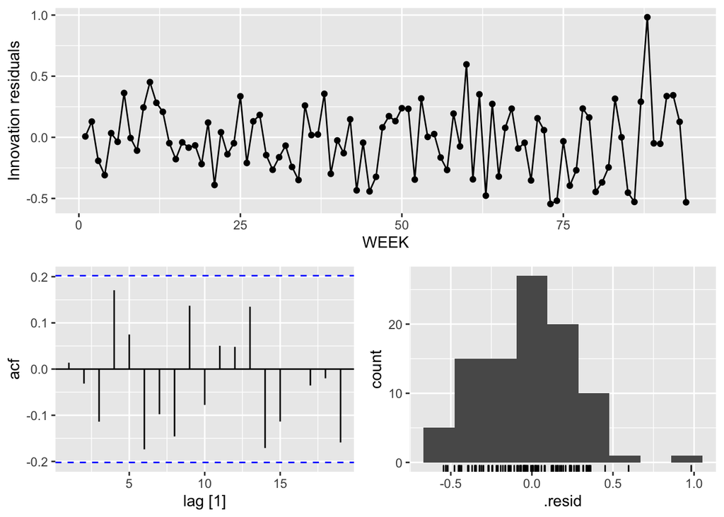

```r
fit_mod_2  %>%  gg_tsresiduals()
```

```r
#performing ljung_box test
fit_mod_2 %>%
  augment() %>%
  features(.resid, ljung_box)
```

| .model | lb_stat | lb_pvalue |
| --- | --- | --- |
| model_2 | 0.01842303 | 0.8920336 |

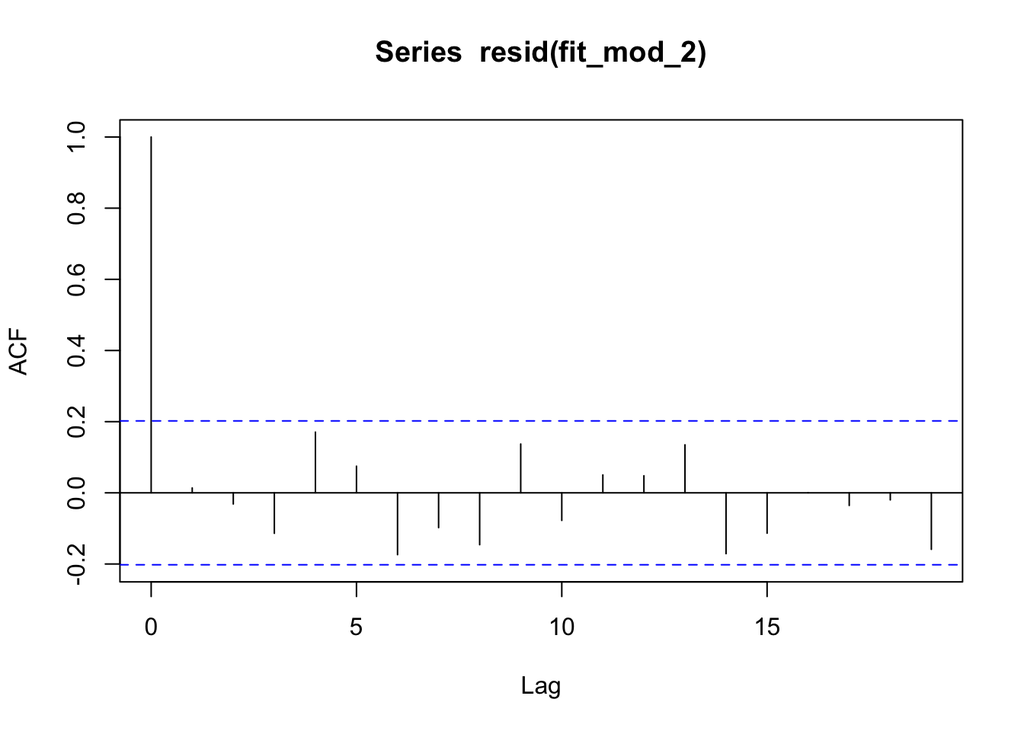

```r
acf(resid(fit_mod_2))
```

As visible from acf, the auto-correlations does not exist between residuals. This is also confirmed by *ljung box* where lb_pvalue is ~0.89. **This is a valid model**

### Ques 6: (5 pts) Obtain a regression with ARIMA errors model that improves on the automatically selected model in Question 5 in terms of its information coefficients and residual diagnostics. Compare the coefficients of the explanatory variables in (a) The Lasso model, (b) The unrestricted model obtained in Question 2, and (c) The ones obtained in this question. Then use the B notation (polynomial) to describe the model you obtained.

**Ans 6:** As automatic selection, we get best model with pdq(0,1,2) in the above question. However, from PACF, it is visible that at lag 3, the residuals are significant. So, we will be fitting the ARIMA model now with **pdq(3,1,2)**

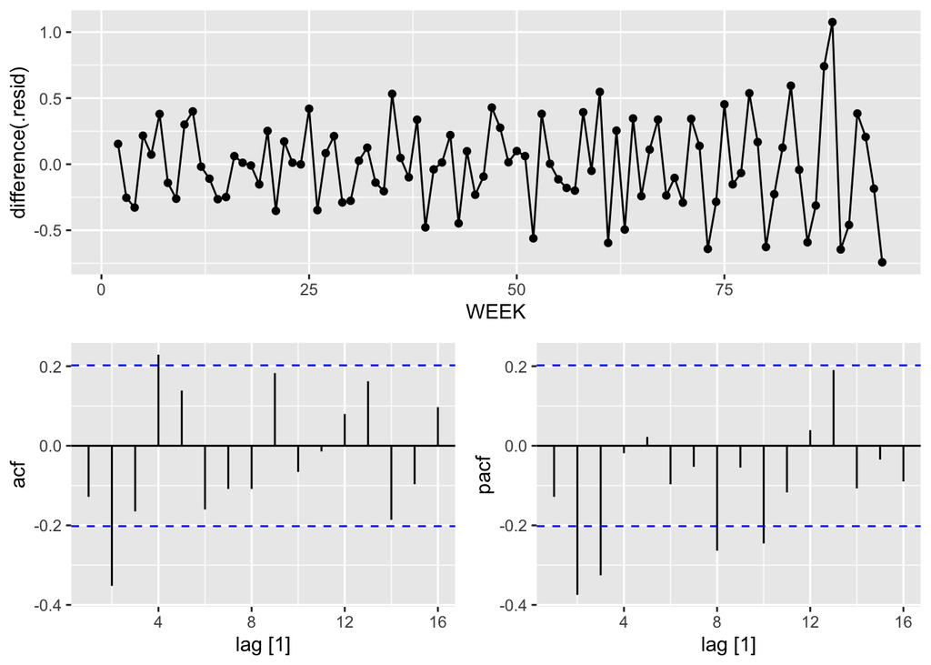

```r
fit_mod_2 %>%  residuals(type="regression") %>%
  gg_tsdisplay(difference(.resid), "partial", lag_max = 16)
```

```r
#pdq(3,1,2)
fit_mod_3 = ARIMA_tr %>% model(mod_3 = ARIMA(LS.SK ~ PPU.SK + WF_LSA.SK:PPU.OB + S.WD.SK:PPU.OB + S.WD.SK:PPU.PL +pdq(3,1,2)))

#printing summary and coefficients
fit_mod_3 %>% glance()
```

| .model | sigma2 | log_lik | AIC | AICc | BIC | ar_roots | ma_roots |
| --- | --- | --- | --- | --- | --- | --- | --- |
| mod_3 | 0.09061957 | -16.00665 | 52.0133 | 54.69623 | 77.3393 |  |  |

```r
fit_mod_3 %>% report()
```

```
## Series: LS.SK
## Model: LM w/ ARIMA(3,1,2) errors
##
## Coefficients:
##           ar1      ar2     ar3      ma1     ma2   PPU.SK  WF_LSA.SK:PPU.OB
##       -0.2144  -0.4667  -0.343  -0.1126  0.0182  -2.6636            0.2743
## s.e.   0.2975   0.3138   0.151   0.2937  0.4390   0.1291            0.1838
##       PPU.OB:S.WD.SK  S.WD.SK:PPU.PL
##              -0.3600          0.7737
## s.e.          0.6016          0.6376
##
## sigma^2 estimated as 0.09062:  log likelihood=-16.01
## AIC=52.01   AICc=54.7   BIC=77.34
```

```r
fit_mod_3
```

| mod_3 |
| --- |

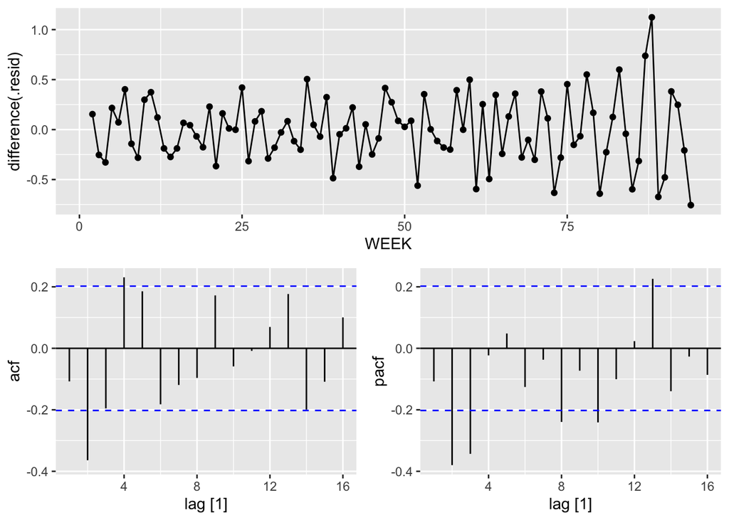

```r
fit_mod_3 %>%  residuals(type="regression") %>%
  gg_tsdisplay(difference(.resid), "partial", lag_max = 16)
```

```r
# performing ljung_box test
fit_mod_3 %>% augment() %>%features(.resid, ljung_box)
```

| .model | lb_stat | lb_pvalue |
| --- | --- | --- |
| mod_3 | 0.001988758 | 0.9644297 |

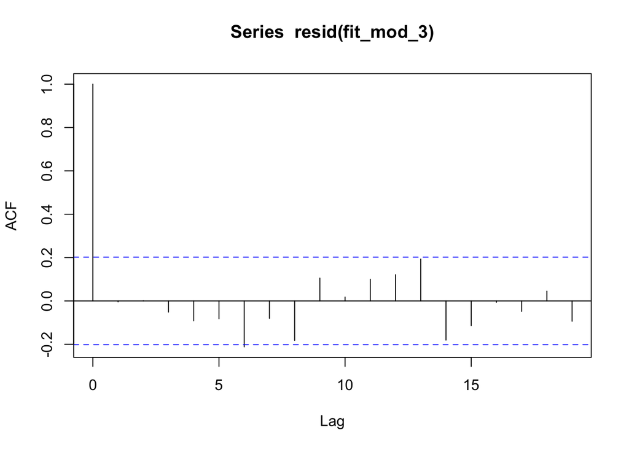

```r
acf(resid(fit_mod_3))
```

As visible from acf, the auto-correlations does not exist between residuals. When we move model from pdf(0,1,2) to pdf(3,1,2), the value of p-value updates from 0.89 to 0.96

**Comparing 3 models:**

```r
three_models =data.frame(coef(lasso_best)[coef(lasso_best)[,1]!=0,][2:5], unrest_lasso$coefficients[2:5],coef(fit_mod_3)$estimate[6:9],coef(fit_mod_2)$estimate[3:6])
colnames(three_models) <- c('Lasso','MLR','ARIMA (3,1,2)','ARIMA (0,1,2)')
three_models
```

|  | Lasso | MLR | ARIMA (3,1,2) | ARIMA (0,1,2) |
| --- | --- | --- | --- | --- |
| PPU.SK | -2.32508143 | -2.5770544 | -2.6635878 | -2.71100010 |
| WF_LSA.SK:PPU.OB | 0.06665459 | 0.5310809 | 0.2742593 | 0.24743565 |
| S.WD.SK:PPU.OB | 0.02517166 | 0.2432813 | -0.3599666 | 0.04401715 |
| S.WD.SK:PPU.PL | 0.58850344 | 0.5044624 | 0.7737368 | 0.41040080 |

**B notation:**

$$(1-B)(LS.SK)_t =
-2.6636(1-B)(PPU.SK)+0.2743(1-B)(WF\_LSA.SK\_PPU.OB)-0.36(1-B)(S.WD.SK\_PPU.OB)+0.7737(1-B)(S.WD.SK\_PPU.PL)+(1-B)n_t$$

### Ques 7: (5 pts) Use the model in Question 5 to prepare a 10 period ahead forecast and compare it (overlay it) with the testing set log-of-sales data. You can also obtain the values of the regressors used in the forecasting model from the testing data set **xm.te**. Comment on the usefulness of this model in terms of precision and confidence interval relative to the model without explanatory variables in Question 3.

**Ans 7:**

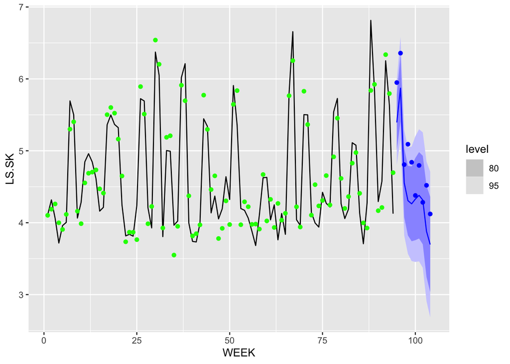

```r
for_mod_3 = fit_mod_3 %>% forecast(new_data = ARIMA_te)

fit_mod = fit_mod_3 %>% augment()

for_mod_3 %>% autoplot(ARIMA_tr) +
          geom_point(data = fit_mod, mapping = aes(y = .fitted), col = "green") +
          geom_point(data = ARIMA_te, mapping = aes(y = LS.SK), col = "blue")
```

```r
rbind(for_mod_3 %>% accuracy(data = ARIMA_te), fit_mod_3 %>% accuracy())
```

| .model | .type | ME | RMSE | MAE | MPE | MAPE | MASE | RMSSE | ACF1 |
| --- | --- | --- | --- | --- | --- | --- | --- | --- | --- |
| mod_3 | Test | 0.415521773 | 0.4820477 | 0.4219185 | 8.311239 | 8.460591 | NaN | NaN | -0.266207443 |
| mod_3 | Training | -0.004404968 | 0.2845684 | 0.2332416 | -0.425607 | 5.089240 | 0.3574544 | 0.3011997 | -0.004527234 |

```r
for_mod_3 %>% hilo(level =95) %>% unpack_hilo("95%") %>% mutate(Actual = ARIMA_te$LS.SK)
```

| .model | WEEK | LS.SK | .mean | WF_LSA.SK | WF_MSA.SK | WF_SSA.SK | S.WD.SK | PPU.SK | WF_LSA.OB | WF_MSA.OB | WF_SSA.OB | S.WD.OB | PPU.OB | WF_LSA.PL | WF_MSA.PL | WF_SSA.PL | S.WD.PL | PPU.PL | 95%_lower | 95%_upper | Actual |
| --- | --- | --- | --- | --- | --- | --- | --- | --- | --- | --- | --- | --- | --- | --- | --- | --- | --- | --- | --- | --- | --- |
| mod_3 | 95 |  | 5.394515 | 0 | 0 | 0.0855845 | 0 | 0.4887711 | 0 | 0 | 0.0000000 | 0.09662870 | 0.7934895 | 0 | 0 | 0 | 0 | 0.7169820 | 4.804505 | 5.984524 | 5.949061 |
| mod_3 | 96 |  | 5.871116 | 0 | 0 | 0.0000000 | 0 | 0.4462433 | 0 | 0 | 0.0000000 | 0.03191942 | 0.9106447 | 0 | 0 | 0 | 0 | 0.8283975 | 5.159932 | 6.582300 | 6.358260 |
| mod_3 | 97 |  | 4.554455 | 0 | 0 | 0.0000000 | 0 | 0.9674052 | 0 | 0 | 0.0000000 | 0.06039770 | 0.8801909 | 0 | 0 | 0 | 0 | 0.7770917 | 3.822341 | 5.286568 | 4.807829 |
| mod_3 | 98 |  | 4.306880 | 0 | 0 | 0.0000000 | 0 | 0.9606028 | 0 | 0 | 0.0000000 | 0.00000000 | 0.9129274 | 0 | 0 | 0 | 0 | 0.8551267 | 3.566651 | 5.047110 | 5.091298 |
| mod_3 | 99 |  | 4.262612 | 0 | 0 | 0.0000000 | 0 | 0.9392872 | 0 | 0 | 0.0000000 | 0.00000000 | 0.9255400 | 0 | 0 | 0 | 0 | 0.8287626 | 3.466309 | 5.058914 | 4.840561 |
| mod_3 | 100 |  | 4.328616 | 0 | 0 | 0.0000000 | 0 | 0.9599857 | 0 | 0 | 0.0000000 | 0.00000000 | 0.9159945 | 0 | 0 | 0 | 0 | 0.8191685 | 3.454419 | 5.202814 | 4.378946 |
| mod_3 | 101 |  | 4.381094 | 0 | 0 | 0.0000000 | 0 | 0.9824575 | 0 | 0 | 0.0000000 | 0.00000000 | 0.9117074 | 0 | 0 | 0 | 0 | 0.8340985 | 3.462394 | 5.299793 | 4.796432 |
| mod_3 | 102 |  | 4.315027 | 0 | 0 | 0.0000000 | 0 | 0.9900079 | 0 | 0 | 0.2399907 | 0.00000000 | 0.8623384 | 0 | 0 | 0 | 0 | 0.7847736 | 3.373801 | 5.256253 | 4.283043 |
| mod_3 | 103 |  | 3.880229 | 0 | 0 | 0.0000000 | 0 | 1.1216605 | 0 | 0 | 0.0000000 | 0.00000000 | 0.8895619 | 0 | 0 | 0 | 0 | 0.8213325 | 2.910149 | 4.850308 | 4.519785 |
| mod_3 | 104 |  | 3.697105 | 0 | 0 | 0.0000000 | 0 | 1.1907675 | 0 | 0 | 0.0000000 | 0.00000000 | 0.9240805 | 0 | 0 | 0 | 0 | 0.7549448 | 2.684170 | 4.710040 | 4.121650 |